# VA 2

Victor Miguel

2024-09-13

# VA 2 Análise de Dados

## VADeaths

Visualize o dataset VADeaths (já incluído no R) e crie um gráfico de barras empilhadas desses dados, de modo que as barras estejam agrupadas (lado a lado) para cada categoria. Também defina uma cor diferente para cada grupo das categorias. Por fim, adicione título, legenda e nomes nos eixos. Abaixo submeta o link do RPubs com o resultado dessa questão. Ela deve ficar dentro de uma aba chamada de “VADeaths”.

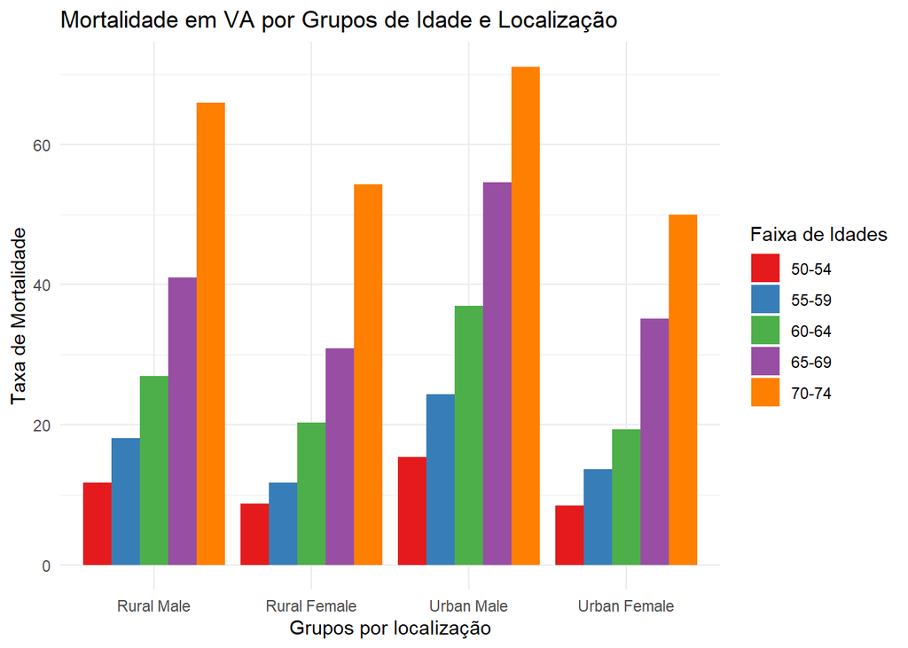

```r
# Carregar as bibliotecas necessárias
library(ggplot2)
library(reshape2)

# Carregar o dataset VADeaths
data("VADeaths")
#View(VADeaths)
# Converter o dataset para formato longo para ggplot
VADeaths_long <- melt(VADeaths)

# Criar o gráfico de barras empilhadas
ggplot(VADeaths_long, aes(x = Var2, y = value, fill = Var1)) +
  geom_bar(stat = "identity", position = "dodge") +
  labs(title = "Mortalidade em VA por Grupos de Idade e Localização",
       x = "Grupos por localização",
       y = "Taxa de Mortalidade",
       fill = "Faixa de Idades") +
  scale_fill_brewer(palette = "Set1") +  # Paleta de cores
  theme_minimal()
```

## ClassificaçãoDoença

Uma doença pode ser classificada em três estágios (leve, moderado e severo). Foram examinados 20 pacientes e obtidos os dados: moderado, leve, leve, severo, leve, moderado, moderado, moderado, leve, leve, severo,leve, moderado, moderado, leve, severo, moderado, moderado, moderado,leve. Com base nestes dados crie um gráfico de piza. Inclua a porcentagem de cada fatia, as cores das fatias e o nome do gráfico. Adicionalmente, use o comando legend() para incluir a legenda do gráfico. Abaixo submeta o link do RPubs com o resultado dessa questão. Ela deve ficar dentro de uma aba chamada de “ClassificaçãoDoença”. Note que apenas um link do RPubs é necessário. Basta repetir o link abaixo se você já tiver submetido para outras questões.

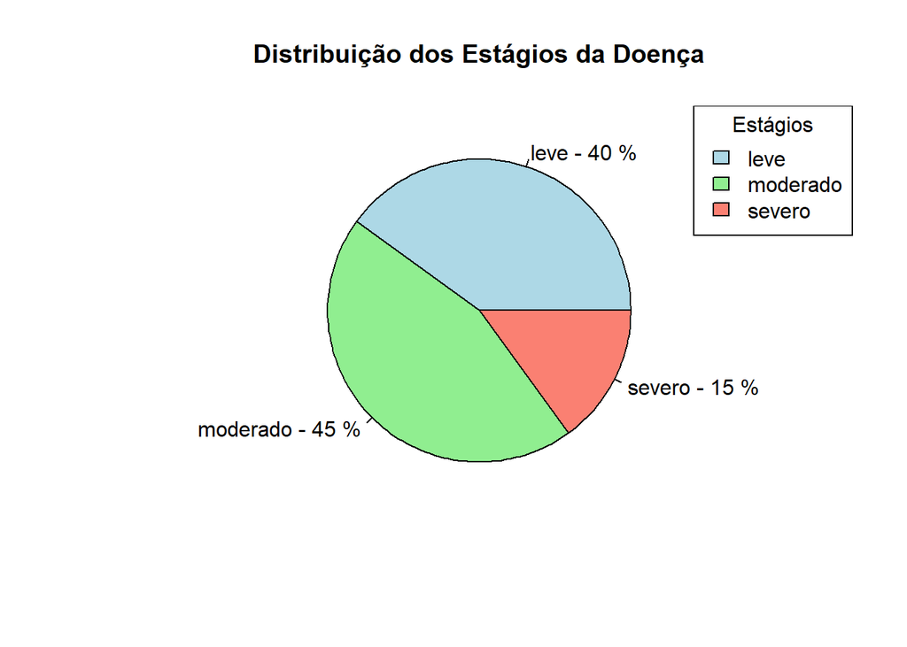

```r
estagios <- c("moderado", "leve", "leve", "severo", "leve", "moderado", "moderado",
              "moderado", "leve", "leve", "severo", "leve", "moderado", "moderado",
              "leve", "severo", "moderado", "moderado", "moderado", "leve")

# Contagem das ocorrências de cada estágio
contagem <- table(estagios)

# Cálculo das porcentagens
porcentagem <- round(100 * contagem / sum(contagem), 1)

# Cores para as fatias
cores <- c("lightblue", "lightgreen", "salmon")

# Criação do gráfico de pizza
pie(contagem,
    labels = paste(names(contagem), "-", porcentagem, "%"),  # Nomes com porcentagem
    col = cores,
    main = "Distribuição dos Estágios da Doença")

# Adicionar legenda ao gráfico
legend("topright", legend = names(contagem), fill = cores, title = "Estágios")
```

## Teorema

Nesta questão, demonstre o uso do teorema do limite central, usando o conjunto de dados “flu” que é altamente não normal. Esse dataset contém as frequências das idades das mortes durante a epidemia de gripe espanhola na Suíça em 1918. Considere a idade das mortes como a população. Execute os passos a seguir. (1)Mostre o histograma e a curva de densidade do conjunto de dados “flu”. (2) Crie 200 médias de amostras da população com tamanho n = 35. (3) Mostre o histograma com a curva de densidade para a médias das amostras. 4) Submeta o link do RPubs com o resultado das etapas anteriores . Essa questão deve ficar dentro de uma aba chamada de “Teorema”. Note que apenas um link do RPubs é necessário. Basta repetir o link abaixo se você já tiver submetido para outras questões.

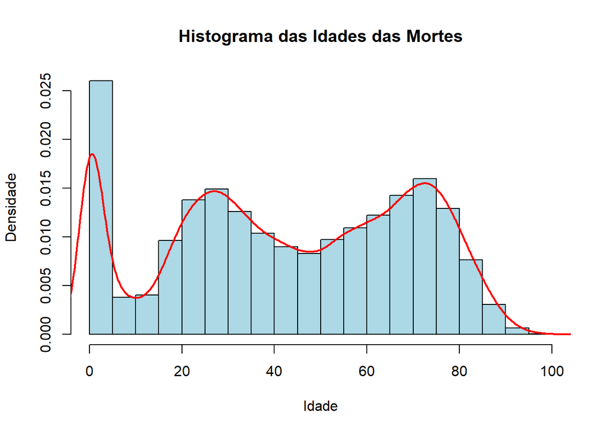

```r
# caminho do arquivo
dados <- read.csv("C:/Users/victo/Downloads/flu.csv", header = TRUE, sep = ",")

# Visualizar as primeiras linhas do dataset
#head(dados)
# Verificar o tipo de dados da coluna
#str(dados)

# Plotar o histograma com curva de densidade
hist(dados$age, freq = FALSE, col = "lightblue", main = "Histograma das Idades das Mortes",
     xlab = "Idade", ylab = "Densidade")

# Adicionar a curva de densidade
lines(density(dados$age), col = "red", lwd = 2)
```

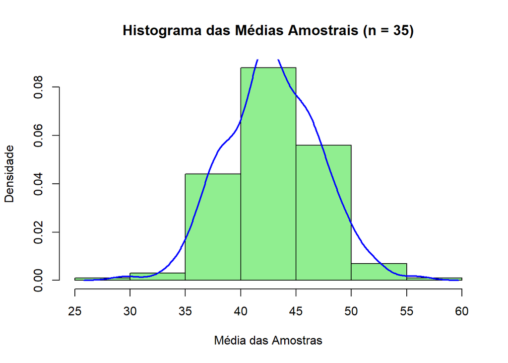

```r
#### pt 2
# Definir o tamanho da amostra
n <- 35

# Criar 200 amostras da população e calcular suas médias
set.seed(123)  #  seed para reprodutibilidade
medias_amostras <- replicate(200, mean(sample(dados$age, size = n, replace = TRUE)))

# Visualizar as primeiras 6 médias
#head(medias_amostras)


# Plotar o histograma das médias das amostras
hist(medias_amostras, freq = FALSE, col = "lightgreen", main = "Histograma das Médias Amostrais (n = 35)",
     xlab = "Média das Amostras", ylab = "Densidade")

# Adicionar a curva de densidade
lines(density(medias_amostras), col = "blue", lwd = 2)
```